# DGP Dossier: synth_placebo_heavytail

## 1. Identity & Status

[output not shown]

## 2. What This DGP Stresses (Intent)

**Intent:** The “Infinite Variance Test.” The data generation contains a mixture of Normal and Cauchy noise. Crucially, the **Cauchy distribution has no defined mean**.

**The Scientific Question:** “Does the estimator fail when the theoretical expectation $E[Y]$ is undefined?” This is a lethal stress test for **Mean-Based Estimators** (OLS, IPW, ATE) which rely on the Central Limit Theorem. Since the mean does not exist, the sample mean will never converge. Only Robust Estimators (e.g., Median/Quantile treatment effects) are theoretically valid here.

## 3. Identification Assumptions (Explicit)

- Selection on observables holds.
- Overlap is moderate (propensity bounded).
- SUTVA holds.
- Sharp Null: $Y_1 \equiv Y_0$.

## 4. Mathematical Specification

Covariates: $X_1, X_2, X_3, X_4, X_5 \sim \mathcal{N}(0, 1^2)$ independently.

**Outcome (control):**
$$\mu_0(X) = 1 + X_1 + 0.5 X_2$$

**Propensity:**
$$p(X) =
\text{expit}(0.5 X_1 - 0.5 X_2)$$

**Treatment effect (sharp null):**
$$\tau(X) \equiv 0$$

**Noise mixture:**
$$\varepsilon \sim 0.8 \cdot \mathcal{N}(0, 0.5^2)
+ 0.2 \cdot \text{Cauchy}(0, 1)$$

Mean and variance are undefined due to the Cauchy component.

## 5. Oracle Truth Definition

- True ATT is zero by construction.
- True QST is identically zero on the canonical grid.

## 6. Visual Diagnostics (n = 5000)

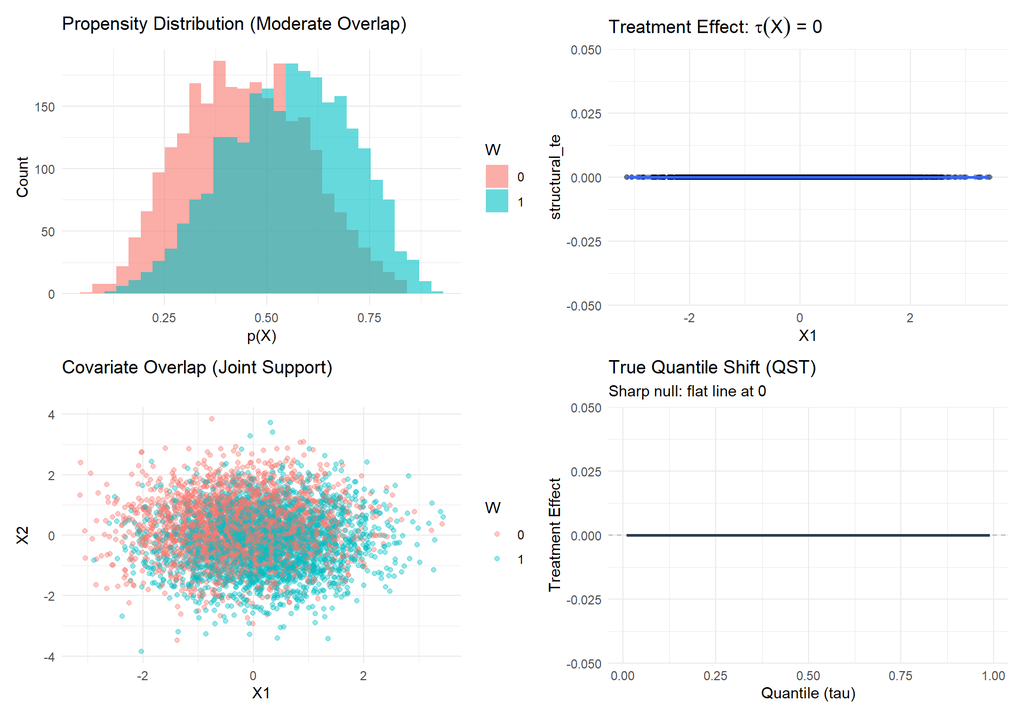

## 7. Empirical Validation

We validate only the oracle estimator to keep builds fast.

Oracle validation (n=1000, seeds=1:20)

| mean_bias | rmse |
| --- | --- |
| 0 | 0 |

## 8. Failure Mode Summary

- **Mean Non-Convergence:** Standard estimators (OLS, IPW) will jump erratically as sample size increases, driven by extreme outliers.
- **Finite Sample Breakdown:** A single extreme value can pull the estimate arbitrarily far from zero, as the estimator chases a mean that doesn’t exist.

## 9. Implementation Reference

- Code: `R/dgp-synth-placebo-heavytail.R` (v1.3.0)
- Registry: `cs_dgp_registry()` entry for `synth_placebo_heavytail`
- Oracle: `true_att = 0`, `true_qst = 0`

## 10. Validation Checklist

- Sharp null enforced ($Y_1 \equiv Y_0$)
- Structural ATT = 0
- QST truth is identically zero
- Oracle validation passes

## 11. Changelog

- v1.0 dossier: Initial placebo dossier

## Appendix: Implementation

```
Source code for: dgp_synth_placebo_heavytail_v130

function(n, seed = NULL, include_truth = TRUE, oracle_only = FALSE) {
  if (!is.null(seed)) {
    cs_set_rng(seed)
  }

  X1 <- stats::rnorm(n, mean = 0, sd = 1)
  X2 <- stats::rnorm(n, mean = 0, sd = 1)
  X3 <- stats::rnorm(n, mean = 0, sd = 1)
  X4 <- stats::rnorm(n, mean = 0, sd = 1)
  X5 <- stats::rnorm(n, mean = 0, sd = 1)

  mu0 <- 1 + X1 + 0.5 * X2
  tau <- rep(0, n)

  p <- stats::plogis(0.5 * X1 - 0.5 * X2)
  w <- stats::rbinom(n, size = 1L, prob = p)

  mix_ind0 <- stats::rbinom(n, size = 1, prob = 0.8)
  eps <- ifelse(
    mix_ind0 == 1L,
    stats::rnorm(n, mean = 0, sd = 0.5),
    stats::rcauchy(n, location = 0, scale = 1)
  )

  y0 <- mu0 + eps
  y1 <- y0
  if (isTRUE(oracle_only)) {
    return(list(df = tibble::tibble(w = w, y0 = y0, y1 = y1)))
  }
  y  <- ifelse(w == 1L, y1, y0)

  true_att <- cs_true_att(structural_te = tau, w = w)
  true_qst <- if (isTRUE(include_truth)) cs_get_oracle_qst("synth_placebo_heavytail", version = "1.3.0") else NULL

  out <- list(
    df = tibble::tibble(
      y  = y,
      w  = w,
```

[output cut: 11 more lines]

```
    true_qst = true_qst,
    meta = list(
      dgp_id        = "synth_placebo_heavytail",
      version       = "1.3.0",
      type          = "synthetic",
      params        = list(n = n, seed = seed),
      structural_te = tau
    )
  )

  cs_check_dgp_synthetic(out)
  out
}
<bytecode: 0x000001d547a48d20>
<environment: namespace:CausalStress>
```